# Prédiction du prix de vente immobilier

### 2.10 PCR (Principal Components Regression)

*Le modèle PCR*

```
## Data:    X dimension: 2625 7
##  Y dimension: 2625 1
## Fit method: svdpc
## Number of components considered: 7
##
## VALIDATION: RMSEP
## Cross-validated using 10 random segments.
##        (Intercept)  1 comps  2 comps  3 comps  4 comps  5 comps  6 comps
## CV           2.034    2.031     1.98    1.993    1.976    1.970    1.969
## adjCV        2.034    2.031     1.98    1.995    1.975    1.969    1.968
##        7 comps
## CV       1.866
## adjCV    1.866
##
## TRAINING: % variance explained
##           1 comps  2 comps  3 comps  4 comps  5 comps  6 comps  7 comps
## X         27.2713   46.825   62.007   76.396    89.04   97.259    100.0
## log_prix   0.3138    4.982    5.008    7.122     7.61    7.949     16.1
```

```
##
## Call:
## lm(formula = pcr1)
##
## Residuals:
##     Min      1Q  Median      3Q     Max
## -9.8169 -0.9718  0.3011  1.2252  5.8740
##
## Coefficients:
##                                        Estimate Std. Error t value Pr(>|t|)
## (Intercept)                           6.541e+01  9.360e+00   6.989 3.51e-12 ***
## sym_quanti$Surface.reelle.bati        1.321e-04  9.473e-05   1.394  0.16330
## sym_quanti$Nombre.pieces.principales  7.354e-01  4.125e-02  17.828  < 2e-16 ***
## sym_quanti$Surface.terrain            3.540e-06  4.820e-06   0.734  0.46272
## sym_quanti$Code.postal               -9.237e-04  1.474e-04  -6.267 4.30e-10 ***
## sym_quanti$Nombre.de.lots             1.343e-01  4.874e-02   2.755  0.00591 **
## sym_quanti$Surface.Carrez.du.1er.lot -1.193e-03  4.474e-03  -0.267  0.78968
## sym_quanti$Code.type.local            1.357e+00  9.261e-02  14.656  < 2e-16 ***
## ---
## Signif. codes:  0 '***' 0.001 '**' 0.01 '*' 0.05 '.' 0.1 ' ' 1
##
## Residual standard error: 1.866 on 2617 degrees of freedom
## Multiple R-squared:  0.161,  Adjusted R-squared:  0.1588
## F-statistic: 71.76 on 7 and 2617 DF,  p-value: < 2.2e-16
```

*Choix du nombre de composants principaux*

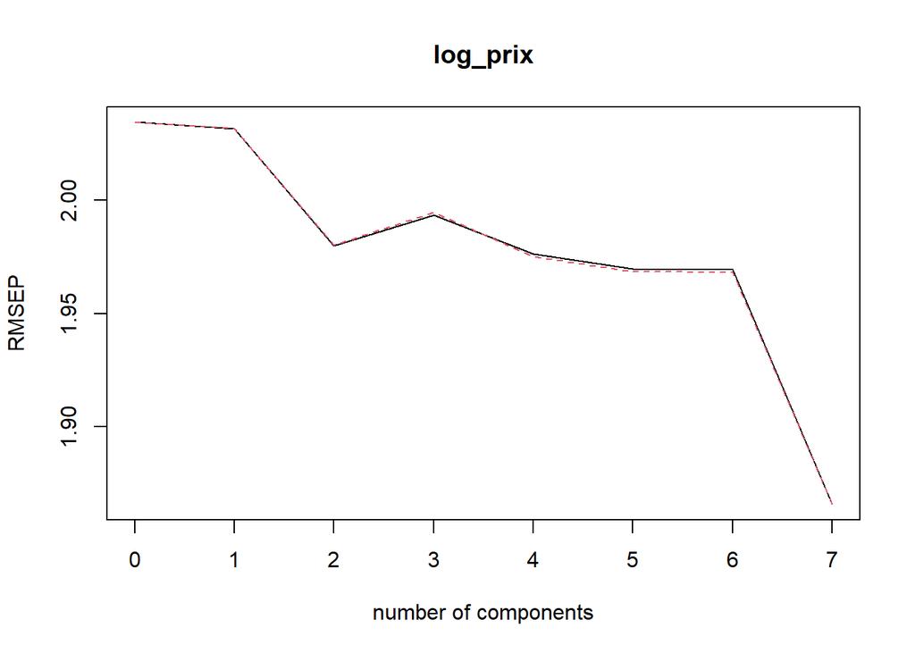

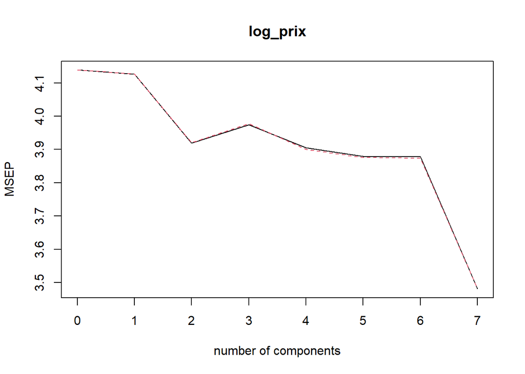

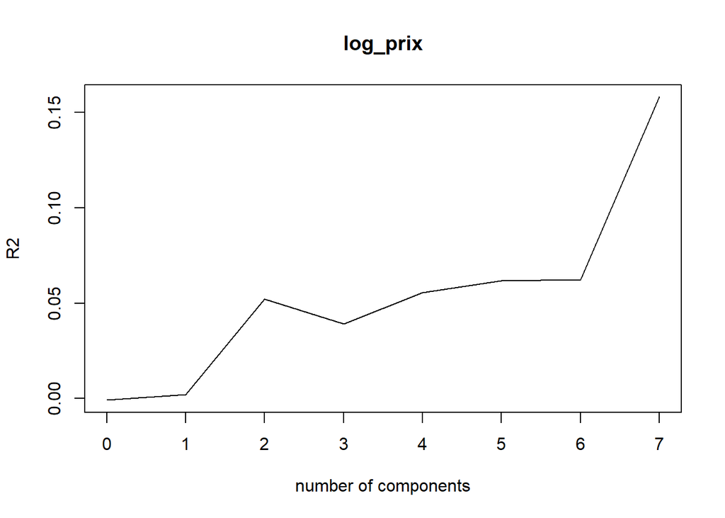

### 2.11 PLS (Partial Least Squares)

```
## Data:    X dimension: 2625 7
##  Y dimension: 2625 1
## Fit method: kernelpls
## Number of components considered: 7
##
## VALIDATION: RMSEP
## Cross-validated using 10 random segments.
##        (Intercept)  1 comps  2 comps  3 comps  4 comps  5 comps  6 comps
## CV           2.034    1.943    1.912    1.880     1.87    1.869    1.869
## adjCV        2.034    1.942    1.911    1.879     1.87    1.869    1.869
##        7 comps
## CV       1.869
## adjCV    1.869
##
## TRAINING: % variance explained
##           1 comps  2 comps  3 comps  4 comps  5 comps  6 comps  7 comps
## X          18.671    33.65    48.56    63.07    72.65    84.88    100.0
## log_prix    9.996    13.35    15.55    16.07    16.10    16.10     16.1
```

```
##
## Call:
## lm(formula = pls1)
##
## Residuals:
##     Min      1Q  Median      3Q     Max
## -9.8169 -0.9718  0.3011  1.2252  5.8740
##
## Coefficients:
##                                        Estimate Std. Error t value Pr(>|t|)
## (Intercept)                           6.541e+01  9.360e+00   6.989 3.51e-12 ***
## sym_quanti$Surface.reelle.bati        1.321e-04  9.473e-05   1.394  0.16330
## sym_quanti$Nombre.pieces.principales  7.354e-01  4.125e-02  17.828  < 2e-16 ***
## sym_quanti$Surface.terrain            3.540e-06  4.820e-06   0.734  0.46272
## sym_quanti$Code.postal               -9.237e-04  1.474e-04  -6.267 4.30e-10 ***
## sym_quanti$Nombre.de.lots             1.343e-01  4.874e-02   2.755  0.00591 **
## sym_quanti$Surface.Carrez.du.1er.lot -1.193e-03  4.474e-03  -0.267  0.78968
## sym_quanti$Code.type.local            1.357e+00  9.261e-02  14.656  < 2e-16 ***
## ---
## Signif. codes:  0 '***' 0.001 '**' 0.01 '*' 0.05 '.' 0.1 ' ' 1
##
## Residual standard error: 1.866 on 2617 degrees of freedom
## Multiple R-squared:  0.161,  Adjusted R-squared:  0.1588
## F-statistic: 71.76 on 7 and 2617 DF,  p-value: < 2.2e-16
```

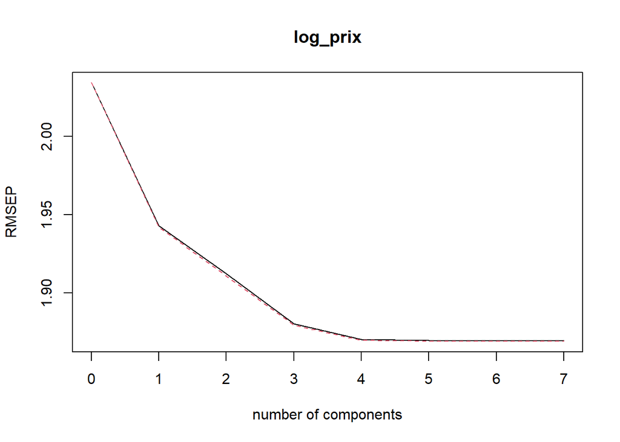

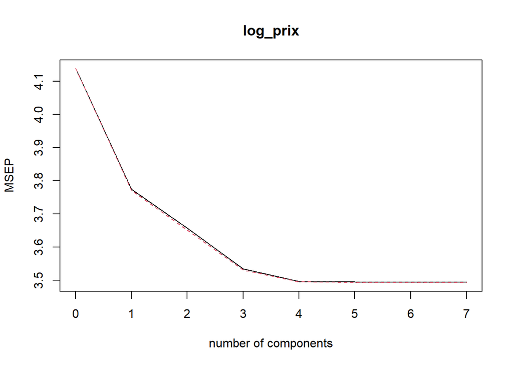

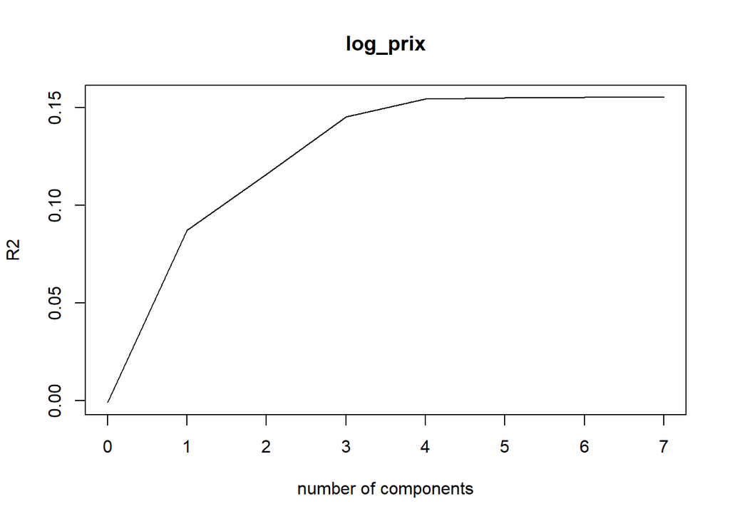

### 2.12 Ridge

```
##           Length Class     Mode
## a0        100    -none-    numeric
## beta      400    dgCMatrix S4
## df        100    -none-    numeric
## dim         2    -none-    numeric
## lambda    100    -none-    numeric
## dev.ratio 100    -none-    numeric
## nulldev     1    -none-    numeric
## npasses     1    -none-    numeric
## jerr        1    -none-    numeric
## offset      1    -none-    logical
## call        4    -none-    call
## nobs        1    -none-    numeric
```

On va maintenant choisir une valeur optimale pour Lambda Pour cela, nous allons identifier la valeur lambda qui produit l’erreur quadratique moyenne de test (MSE) la plus faible en utilisant la validation croisée k-fold.

```
## [1] 0.03864425
```

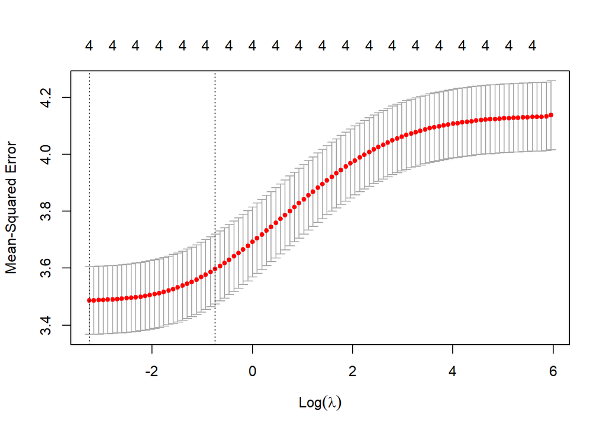

```
## 5 x 1 sparse Matrix of class "dgCMatrix"
##                                      s0
## (Intercept)               65.8484361995
## Nombre.pieces.principales  0.6848061648
## Code.postal               -0.0009268439
## Nombre.de.lots             0.1399323196
## Code.type.local            1.2505540227
```

Nous pouvons également produire un diagramme de trace pour visualiser comment les estimations de coefficients ont changé à la suite de l’augmentation de lambda :

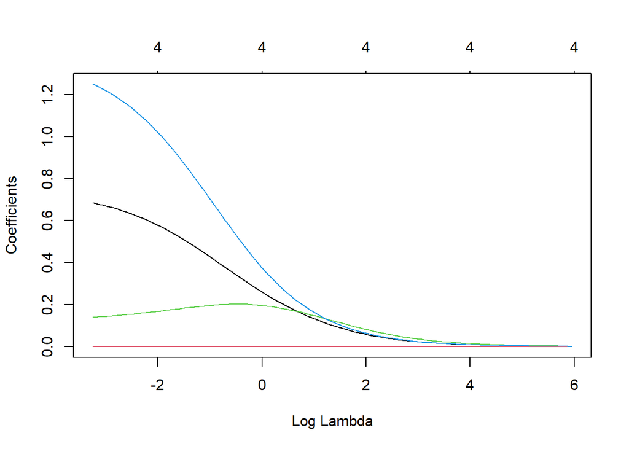

Enfin, nous pouvons calculer le R-carré du modèle sur les données d’entraînement :

```
## [1] 0.1594908
```

Le R-carré s’avère être 0.1595.

### 2.13 Lasso

```
##           Length Class     Mode
## a0         59    -none-    numeric
## beta      236    dgCMatrix S4
## df         59    -none-    numeric
## dim         2    -none-    numeric
## lambda     59    -none-    numeric
## dev.ratio  59    -none-    numeric
## nulldev     1    -none-    numeric
## npasses     1    -none-    numeric
## jerr        1    -none-    numeric
## offset      1    -none-    logical
## call        4    -none-    call
## nobs        1    -none-    numeric
```

Il faut noter que définir alpha = 0 équivaut à utiliser la regression ridge, alpha = 1 équivaut à utiliser la régression Lasso et définir alpha sur une valeur comprise entre 0 et 1 équivaut à utiliser un réseau élastique.

On va maintenant choisir une valeur optimale pour Lambda Pour cela, nous allons identifier la valeur lambda qui produit l’erreur quadratique moyenne de test (MSE) la plus faible en utilisant la validation croisée k-fold.

```
## [1] 0.00175247
```

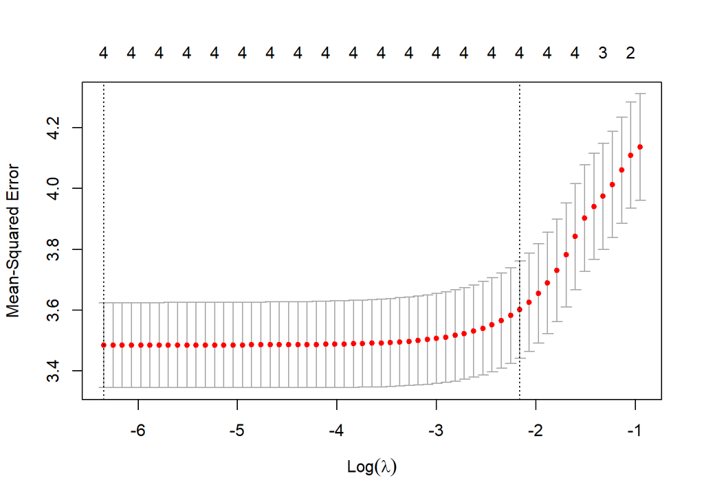

Enfin, nous pouvons calculer le R-carré du modèle sur les données d’entraînement :

```
## [1] 0.1601688
```

Le R-carré s’avère être 0,1601, il est un tout petit meilleur que celui obtenu lors de la régression Ridge (0,159).

### 2.14 Elastic net

L’Elastic net ce base sur les mêmes choses que pour le Lasso et le Ridge, ce qui va changer est la valeur du alpha (qui vaut 0 dans le cas d’une regression Ridge, 1 dans le cas d’une regression Lasso puis ici entre 0 et 1 pour un Elastic net).

```
##           Length Class     Mode
## a0         63    -none-    numeric
## beta      252    dgCMatrix S4
## df         63    -none-    numeric
## dim         2    -none-    numeric
## lambda     63    -none-    numeric
## dev.ratio  63    -none-    numeric
## nulldev     1    -none-    numeric
## npasses     1    -none-    numeric
## jerr        1    -none-    numeric
## offset      1    -none-    logical
## call        4    -none-    call
## nobs        1    -none-    numeric
```

On va maintenant choisir une valeur optimale pour Lambda Pour cela, nous allons identifier la valeur lambda qui produit l’erreur quadratique moyenne de test (MSE) la plus faible en utilisant la validation croisée k-fold.

```
## [1] 0.002415819
```

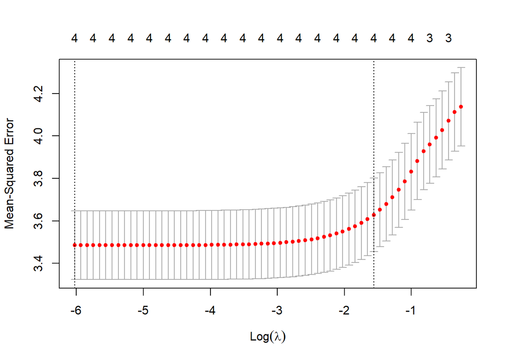

```
## [1] 0.1601684
```

**Tableau récapitulatif :**

|  | R² | RMSE | MAE | Lambda |
| --- | --- | --- | --- | --- |
| PCR | 0.1610338 | 1.971812 | 1.497674 |  |
| PLS | 0.1610338 | 1.888546 | 1.427390 |  |
| Ridge | 0.1594908 | 1.875406 | 1.413430 | 0.04 |
| Lasso | 0.1601688 | 1.874629 | 1.414154 | 0 |
| Elastic net | 0.1601684 | 1.874629 | 1.414155 | 0 |

Les R² sont quasi identiques pour tous les modèles, autour de 0.16. Cela signifie que tous les modèles expliquent environ 16 % de la variance, ce qui est faible.

Les meilleurs RMSE sont obtenus par Ridge, Lasso et Elastic Net, quasiment identiques.PCR est clairement le moins performant.

Le meilleur MAE est obtenu par Ridge (1.413), suivi de très près par Lasso et Elastic Net.

# Conclusion :

L’ensemble des modèles testés : régression linéaire classique et modèles linéaires généralisés, montrent que plusieurs variables explicatives contribuent significativement à la prédiction du prix immobilier, mais que la capacité globale de ces modèles à expliquer la variabilité du prix reste limitée.

Les méthodes de régression régularisée et de réduction de dimension : PCR, PLS, Ridge, Lasso et Elastic Net, ont été évaluées afin d’examiner leur capacité à améliorer la prédiction du prix immobilier. Les résultats obtenus montrent que, malgré des approches méthodologiques différentes, ces modèles n’apportent qu’une amélioration marginale par rapport aux modèles linéaires classiques.

La régression linéaire appliquée au logarithme du prix met en évidence l’importance de certaines caractéristiques structurelles du bien, notamment le **nombre de pièces principales**, le **code postal**, le **nombre de lots** et le **type de local**, qui apparaissent systématiquement significatifs. En revanche, d’autres variables comme la **surface réelle bâtie**, la **surface du terrain** ou la **surface Carrez du premier lot** n’apportent pas d’effet statistiquement marqué dans ce cadre.

Le GLM gaussien avec lien logarithmique confirme globalement ces résultats : les mêmes variables ressortent significatives, et les coefficients conservent une interprétation cohérente avec celle du modèle linéaire. Les critères d’information (AIC, BIC) montrent que ce modèle offre un ajustement légèrement meilleur, tandis que la régression linéaire conserve une erreur de prédiction (RMSE) marginalement plus faible. Les tests statistiques indiquent par ailleurs que, malgré des structures de variance différentes, **aucun des deux modèles ne surpasse significativement l’autre en termes de qualité d’ajustement globale**.

Dans l’ensemble, ces résultats suggèrent que les relations entre les caractéristiques du bien et son prix de vente sont **partiellement capturées par des modèles linéaires**, mais qu’une part importante de la variabilité demeure inexpliquée. Cela peut refléter la présence d’effets non linéaires, ou encore l’influence de facteurs non observés.

Ainsi, bien que les modèles linéaires fournissent une base solide pour la prédiction du prix immobilier, l’amélioration de la performance prédictive pourrait nécessiter des approches, telles que des modèles non linéaires, des méthodes d’apprentissage automatique ou l’intégration de nouvelles variables explicatives.